# Final Presentation

Dylan Sun & Zijiang Yang

2017-01-26

# Objectives

- Determine predictors of erectile function preservation after SBRT
- Determine the erectile function rates following SBRT
- Determine who is likely to have erectile function

# Potential Predictors

Negatively Associated: - Age, Gleason Score, T-stage, PSA, ADT, BMI

Positively Associated: - HRQOL, Erectile Function at Baseline

We expect HRQOL and Erectile Function at Baseline to be highly correlated, because erectile function is included in the questionnaire.

# How many people lose function?

- At baseline: 158 with function, 167 without (0.49)
- At two years: 102 with function, 223 without (0.31)
- A seemingly large number of people lose function in just two years

| never_functional | gain_function | loss_function | retain_function |
| --- | --- | --- | --- |
| 153 | 14 | 70 | 88 |

# Data processing

- Age was centered
- Gleason score was collapsed into “low” (GS <= 6), “medium” (GS == 7), and “high” (GS >= 8)
- T-Stage group was collapsed into two categories, 0 and 1; the lone patient with T-Stage group >= 2 went into the 1 group.

# Model

# Results

**Logistic regression results**

|  | For Erectile function at baseline: |
| --- | --- |
|  | Odds ratios for one unit change (95% CI) |
| centered_age | 0.943** (0.899, 0.988) |
| `Gleason Score` | 0.904 (0.523, 1.561) |
| `T-Stage Group` | 0.603 (0.212, 1.715) |
| PSA | 1.063* (0.994, 1.137) |
| HRQOL | 1.023*** (1.007, 1.040) |
| ADT | 0.483 (0.148, 1.581) |
| BMI | 0.979 (0.923, 1.038) |
| `Erectile Function at Baseline` | 4.299*** (1.824, 10.132) |
| Observations | 325 |
| *Note:* | p<0.1; p<0.05; p<0.01 |

# Results

- Hosmer-lemeshow test:
- X-squared value of 6.8019
- p-value of 0.5581
- We fail to find any evidence of lack of goodness of fit
- 10-fold CV: raw estimate ~ 0.24
- cost function: mean number incorrect at threshold = 0.5

# Results

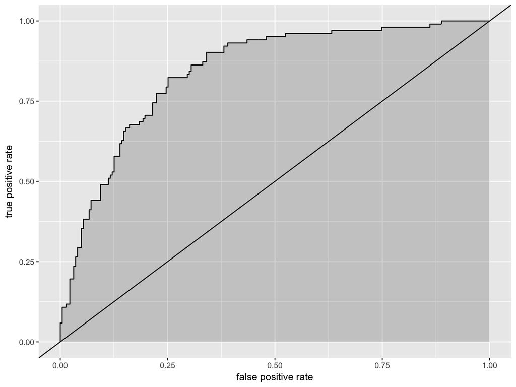

ROC Curve

# Error rates

- AUC = 0.842
- Threshold = 0.426 found using Euclidean distance
- 38 percent predicted to have erectile function at two years; from 49 percent at baseline (0.225 error rate)
- Using 0.5 as the cutoff, 30 percent expected to retain (0.206 error rate)
- In dataset, 31 percent of patients had function at two years
- Calculated threshold is more optimistic and encourages treatment

# Conclusions

# Recommendations

- Younger men, with high HRQOL scores and high PSA levels, and have erectile function at baseline will likely retain their erectile function

| cen_age | Gleason Score | T_Stage | PSA | HRQOL | ADT | BMI | Erec_base | prob_func | pred_func |
| --- | --- | --- | --- | --- | --- | --- | --- | --- | --- |
| -7.14 | 1 | 0 | 32.5 | 88 | 0 | 25 | 1 | 0.92 | 1 |
| 7.86 | 2 | 1 | 9.5 | 25 | 1 | 27 | 1 | 0.06 | 0 |